# Week 2: Removing ambient RNA with SoupX (the automated route)

Kevin Z. Lin

2026-08-03

# 1 Overview

This overview was made from https://rawcdn.githack.com/constantAmateur/SoupX/204b602418df12e9fdb4b68775a8b486c6504fe4/inst/doc/pbmcTutorial.html.

When you sequence a droplet-based single-cell experiment, some cells break open before they are captured. Their mRNA spills into the solution that everything is suspended in, and that free-floating mRNA gets pipetted into droplets alongside the intact cells. The sequencer cannot tell the difference. Every droplet therefore contains a mixture: the mRNA of the cell that was actually captured, plus a little of the mRNA of whatever else was floating around.

The SoupX authors call that free-floating mixture **the soup**. This tutorial is about measuring how much soup ended up in each of your cells and subtracting it.

Two properties of the soup make it tractable:

- The soup is made of lysed cells from *your* sample, so its composition looks like the average of your own cells. It is not a generic contaminant — it is experiment-specific, and it must be estimated from your data every time.
- Most droplets in a run contain no cell at all. Those empty droplets contain soup and nothing else, which means the soup can be observed directly.

The method has three steps, and the whole tutorial is just these three steps with diagnostics in between:

| Step | What it produces | Function |
| --- | --- | --- |
| 1. Profile the soup | What the contamination looks like: the relative abundance of every gene in the background | `estimateSoup` (run automatically) |
| 2. Estimate the contamination fraction | What proportion of each cell’s counts came from the soup, a number called `rho` | `autoEstCont` |
| 3. Correct the counts | A cleaned count matrix to use downstream instead of the raw one | `adjustCounts` |

`rho` is the number to keep your eye on. `rho = 0` means no contamination; `rho = 1` would mean a droplet is 100% soup. Typical fresh-tissue experiments land somewhere around 0.05 to 0.10, but nuclei preparations and necrotic or complex tissue can run considerably higher — which is exactly why you measure it rather than assume it. (The demonstration dataset below comes in *lower* than that typical range, which turns out to be instructive in its own right.)

**This tutorial takes the fully automated route.** Step 2 is the hard one, and SoupX ships an automatic estimator for it. We will use that estimator and trust it. The companion script, `soupx_handson.R`, does the same job the manual way — which is what you will need if your data did not come out of CellRanger.

> **A note on where this sits in the workflow.** Ambient RNA removal happens *before* the Week 1 pipeline, not inside it. You start with a raw count matrix, clean it here, and then hand the cleaned matrix to `CreateSeuratObject()` and carry on as in Week 1.

# 2 Setting up

SoupX is on CRAN, so it installs like any other R package. You only need to do this once, which is why the line is commented out — remove the `#` the first time you run it.

```r
# install.packages("SoupX")
```

We will use three packages. `SoupX` does the work; `Matrix` provides functions for *sparse* matrices (count matrices are mostly zeros, so they are stored in a compressed format that base R’s `rowSums` does not understand); `ggplot2` is for plotting.

```r
library(SoupX)
library(Matrix)
library(ggplot2)
```

Throughout this document you will see functions written as `SoupX::load10X()` rather than just `load10X()`. The `::` says “the `load10X` function from the `SoupX` package.” It is redundant once you have run `library(SoupX)`, but it makes it unambiguous where every function came from, which is genuinely useful when you are reading code in a language you are still learning.

```r
rm(list = ls())
```

# 3 Getting the data

We will use a 10x Genomics demonstration dataset: about 1,000 PBMCs (peripheral blood mononuclear cells) from a healthy donor, from [this 10x dataset page](https://www.10xgenomics.com/datasets/human-pbmc-from-a-healthy-donor-1-k-cells-v-2-2-standard-4-0-0).

SoupX needs **three** things from a CellRanger run, and it is worth being explicit about why, because the third one is easy to overlook:

1. `raw_feature_bc_matrix/` — **every** droplet barcode, including the hundreds of thousands of empty ones. This is what the soup profile is estimated from. Without it there are no empty droplets and there is nothing to measure.
2. `filtered_feature_bc_matrix/` — only the barcodes CellRanger called as real cells. This is the matrix that gets corrected.
3. `analysis/` — CellRanger’s own clustering and dimension reduction. SoupX does not cluster your data, but the automatic estimator in step 2 needs clusters to work, and the correction in step 3 is substantially better with them.

The code below downloads all three into a temporary folder and unpacks them. `tempdir()` is a scratch directory that R deletes when you quit, so nothing is left behind on your machine; if you would rather keep the files, replace `tmp_dir` with a real path of your own.

```r
tmp_dir <- tempdir(check = TRUE)
base_url <- "https://cf.10xgenomics.com/samples/cell-vdj/4.0.0/sc5p_v2_hs_PBMC_1k/sc5p_v2_hs_PBMC_1k"

for (component in c("raw_feature_bc_matrix",
                    "filtered_feature_bc_matrix",
                    "analysis")) {
  destination <- file.path(tmp_dir, paste0(component, ".tar.gz"))
  download.file(paste0(base_url, "_", component, ".tar.gz"),
                destfile = destination)
  untar(destination, exdir = tmp_dir)
}

data_dir <- tmp_dir
```

Each archive unpacks to a folder named after itself, so after this runs `tmp_dir` contains exactly the three folders SoupX is looking for.

**If you are using your own data instead**, skip the chunk above and point `data_dir` at your CellRanger output folder — the one containing `raw_feature_bc_matrix/`, `filtered_feature_bc_matrix/`, and `analysis/`. That is usually the `outs/` directory of a CellRanger run.

```r
data_dir <- "/Users/kevinlin/Library/CloudStorage/Dropbox/Collaboration-and-People/sumie-katie/data/seurat-pbmc_v2/"
```

# 4 Loading the data

`load10X()` reads all three components and assembles them into a **`SoupChannel`** object. A “channel” is one 10x run — one sample loaded onto one lane. Contamination is estimated per channel, because each channel has its own soup.

```r
sc <- SoupX::load10X(data_dir)
sc
```

A `SoupChannel` is just a list with some structure. The pieces that matter:

- `sc$toc` — the **t**able **o**f **c**ounts: genes × cells, the real cells only.
- `sc$tod` — the **t**able **o**f **d**roplets: genes × *all* droplets, empties included.
- `sc$soupProfile` — the estimated soup, added automatically on load (this is step 1, already done).
- `sc$metaData` — one row per cell. Because we gave it `analysis/`, this already contains CellRanger’s cluster assignments and tSNE coordinates.

```r
dim(sc$toc)
```

```
## [1] 36601   972
```

```r
head(sc$metaData)
```

```
##                    nUMIs clusters clustersFine      tSNE1      tSNE2
## AAACCTGCAGCCTGTG-1  5029        2            1   2.648850 20.9739145
## AAACGGGTCGCTGATA-1  4343        2            1   3.794655 14.2577198
## AAAGATGTCCTCGCAT-1   898        2            4 -13.917112 -0.5015150
## AAAGCAAAGTATGACA-1  4999        1            1   6.024173 16.0463731
## AAAGCAATCCATTCTA-1   601        3            4 -14.522932  1.3257552
## AAATGCCCACTTAAGC-1  4998        1            1  25.030446 -0.8199953
```

> **A gotcha worth knowing about.** This particular dataset contains two kinds of features: 36,601 genes and 19 antibody-capture tags. `load10X()` keeps only `Gene Expression` by default, which is what we want. If you load a multi-modal dataset with `Seurat::Read10X()` directly you get a *list* of matrices instead of one matrix, and code written for a single matrix will fail in confusing ways. Check `dim()` on anything you load.

# 5 Profiling the soup

Step 1 already happened inside `load10X()`, but it is worth seeing what it did. The soup profile is estimated from droplets with very few UMIs — by default, those with fewer than 100 — on the assumption that such droplets contain no cell and therefore contain nothing but background. Each gene gets a fraction: its share of all the counts observed across those empty droplets.

```r
head(sc$soupProfile[order(sc$soupProfile$est, decreasing = TRUE), ], n = 20)
```

```
##                est counts
## MALAT1 0.026916477   7278
## EEF1A1 0.012892393   3486
## RPLP1  0.010077961   2725
## RPS27  0.009656351   2611
## RPL41  0.009641557   2607
## RPS12  0.009478831   2563
## B2M    0.008887097   2403
## TMSB4X 0.008813131   2383
## RPL13  0.008753957   2367
## RPL10  0.008354537   2259
## RPL32  0.007337495   1984
## ACTB   0.007259830   1963
## RPL39  0.007230243   1955
## RPL34  0.007100802   1920
## RPS27A 0.006904790   1867
## RPS15A 0.006860410   1855
## RPL30  0.006816030   1843
## MT-CO1 0.006745762   1824
## RPS28  0.006682890   1807
## RPL28  0.006642208   1796
```

The `est` column is that fraction, and the genes at the top are the ones most abundant in the background. `MALAT1` leads at about 2.7%, followed by a long run of ribosomal protein genes (`RPLP1`, `RPS27`, `RPL41`, `RPS12`, …) plus `EEF1A1`, `B2M`, `TMSB4X`, and `ACTB`, with the mitochondrial gene `MT-CO1` appearing partway down.

That list is the expected signature of mRNA released by cells that fell apart: the housekeeping transcripts every cell makes in bulk. Seeing it is a reassuring sign that the estimate is behaving. If instead the top of this list were a tight set of markers for one cell type, you would suspect that a population lysed preferentially — which is itself worth knowing.

Notice also what is *not* here. `LYZ`, the gene we are about to worry about, does not make the top 20 of the soup. It does not need to: what matters is not a gene’s absolute rank in the background but the *ratio* of soup-derived counts to genuine counts in the cells you are looking at. In a T cell, whose true `LYZ` expression is zero, even a modest amount of soup is infinitely more than it should have.

Notice what this means: the contamination is not a random smear across all genes. It is concentrated in genes that are highly expressed in whichever cells lysed. A gene that is abundant in the soup will be added to *every* cell, including cell types that never express it.

# 6 A first look at the data

Before correcting anything, let us see the data as CellRanger clustered it. `load10X()` pulled these cluster labels and tSNE coordinates from `analysis/`, so nothing needs to be computed here.

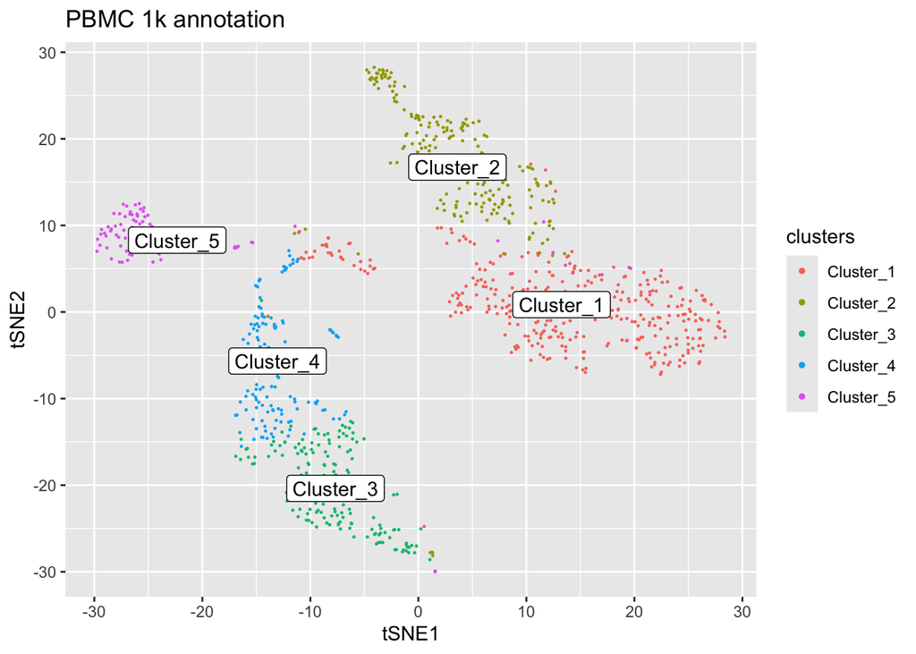

```r
dd <- sc$metaData[colnames(sc$toc), ]
dd$clusters <- as.factor(paste0("Cluster_", dd$clusters))

mids <- aggregate(cbind(tSNE1, tSNE2) ~ clusters, data = dd, FUN = mean)

gg <- ggplot2::ggplot(dd, ggplot2::aes(tSNE1, tSNE2)) +
  ggplot2::geom_point(ggplot2::aes(colour = clusters), size = 0.2) +
  ggplot2::geom_label(data = mids, ggplot2::aes(label = clusters)) +
  ggplot2::ggtitle("PBMC 1k annotation") +
  ggplot2::guides(colour = ggplot2::guide_legend(override.aes = list(size = 1)))
plot(gg)
```

Reading that code, line by line: `dd` is the per-cell metadata, subset to the cells in the count table and in the same order. `aggregate()` computes the mean tSNE position within each cluster, which is where the labels get drawn. `geom_point` draws the cells and `geom_label` draws the cluster names on top. The `override.aes` argument only enlarges the dots in the legend — at `size = 0.2` they would otherwise be invisible there.

## 6.1 Why we suspect contamination in the first place

Take `LYZ`, the gene for lysozyme. It is a classic marker of monocytes and other myeloid cells, and it is expressed at very high levels in them. In a PBMC sample it should be essentially confined to the monocyte cluster — a T cell has no business making lysozyme.

`LYZ` is a good gene to be suspicious about for a specific reason. The soup is made from cells that lysed, and a gene that is *abundantly* expressed in some population contributes correspondingly heavily to the soup. Highly expressed, highly cell-type-specific genes are therefore the ones most likely to show up where they do not belong.

`plotMarkerMap()` asks a sharper question than “where is this gene expressed?” For each cell it computes how many `LYZ` counts we would expect *if that cell contained nothing but soup*, and colours the cell by the ratio of observed to expected. Red means far more than the soup could explain — real expression. Blue means at or below what the soup alone would produce — consistent with pure contamination. Black dots are cells with zero counts for the gene.

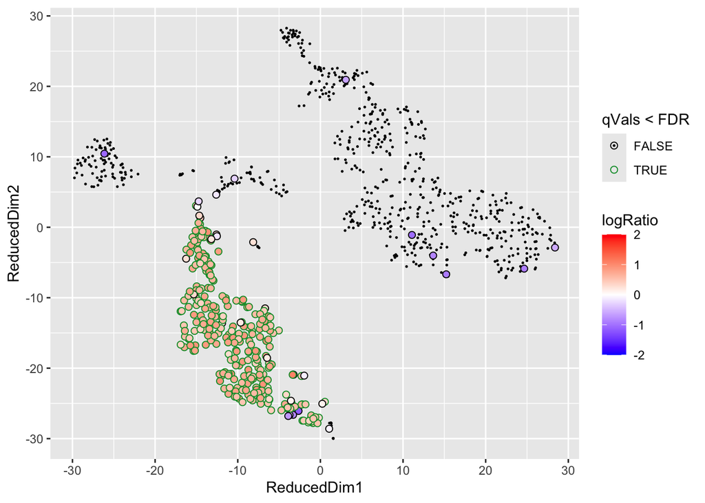

```r
gg <- SoupX::plotMarkerMap(sc, "LYZ")
plot(gg)
```

You should see the monocyte cluster come out red, as it should be. But `LYZ` is typically *also* detected, faintly, in cells scattered across the lymphocyte clusters. Taken at face value, that is a population of lysozyme-producing T cells. The blue colouring says otherwise: in those cells the `LYZ` counts are entirely consistent with what a droplet of pure soup would contain.

(The SoupX vignette makes this same point with `IGKC`, an antibody gene that should be confined to B cells. The logic is identical — pick a gene that is strongly expressed in exactly one population and check whether it stays there.)

This is the practical reason to care about ambient RNA. It does not just add noise; it manufactures expression in cell types that do not express the gene, and it does so most visibly for genes that are strongly expressed in *some* cluster. Those are precisely the marker genes you would use to identify cell types.

# 7 Estimating the contamination fraction

Now step 2 — estimating `rho`. This is the part that used to require real effort from the user, and `autoEstCont()` is the automation of it.

The idea underneath is simple. If we can find genes that a given cell certainly does *not* express, then every count of those genes in that cell must have come from the soup, and comparing that count to the soup profile gives an estimate of `rho`. `autoEstCont()` finds such genes automatically: it identifies genes highly specific to one cluster, and then, for every *other* cluster, treats them as genes that should be absent. Each gene–cluster pair yields its own independent estimate of `rho`.

That gives hundreds of estimates. The trick to combining them is an assumption about how they fail: wrong estimates have no particular preferred value and scatter, while correct estimates all cluster around the truth. So the most common value wins.

```r
sc <- SoupX::autoEstCont(sc)
```

```
## 219 genes passed tf-idf cut-off and 123 soup quantile filter.  Taking the top 100.
```

```
## Using 257 independent estimates of rho.
```

```
## Estimated global rho of 0.01
```

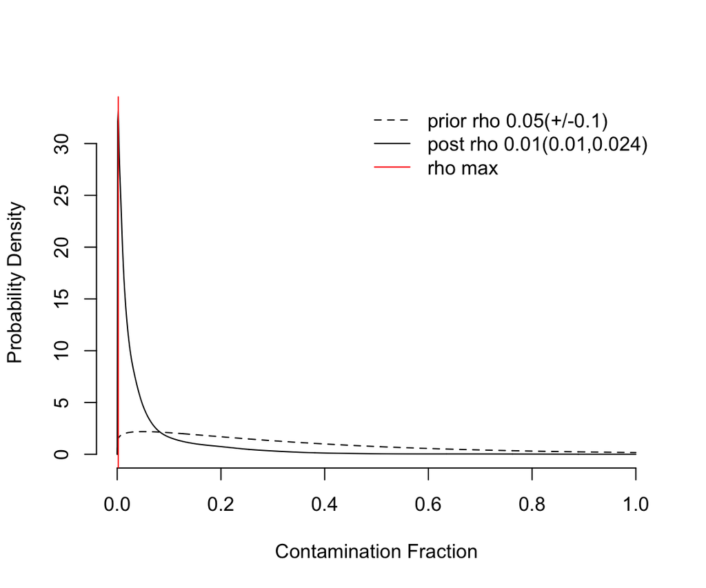

The function reports how many genes survived its filters, how many independent estimates it used, and the final global `rho`. Reading the plot:

- The **solid curve** is the combined evidence across all the gene–cluster estimates — essentially where the estimates pile up.
- The **red vertical line** is its peak. That is the estimate SoupX adopts.
- The **dashed curve** is the prior. With the default settings it is deliberately weak and you can ignore it. It exists so the estimator degrades gracefully when there is little information in the data, not to push the answer anywhere.

The estimate is stored on the object and applies to every cell:

```r
head(sc$metaData)
```

```
##                    nUMIs clusters clustersFine      tSNE1      tSNE2  rho
## AAACCTGCAGCCTGTG-1  5029        2            1   2.648850 20.9739145 0.01
## AAACGGGTCGCTGATA-1  4343        2            1   3.794655 14.2577198 0.01
## AAAGATGTCCTCGCAT-1   898        2            4 -13.917112 -0.5015150 0.01
## AAAGCAAAGTATGACA-1  4999        1            1   6.024173 16.0463731 0.01
## AAAGCAATCCATTCTA-1   601        3            4 -14.522932  1.3257552 0.01
## AAATGCCCACTTAAGC-1  4998        1            1  25.030446 -0.8199953 0.01
```

## 7.1 This dataset is unusually clean, and that is worth pausing on

The `rho` column reads **0.01** for every cell — about 1% of counts attributed to soup. That is low. For comparison, the SoupX vignette’s PBMC dataset gives 0.06, and brain nuclei preparations routinely run higher still.

More than that, 0.01 is exactly the **lower bound of `autoEstCont()`’s search range** (the `contaminationRange = c(0.01, 0.8)` argument). The function finds the peak of the evidence curve *within* that range, so an answer sitting precisely on the boundary tells you the peak wanted to be at or below the edge. The honest reading is “this channel has very little ambient contamination — 1% or less,” not “the contamination is 1.00%.”

This is a good thing to have met once. Two lessons:

- **A boundary value is a signal, not just a number.** Any time an optimizer returns exactly the edge of its allowed range, check whether the range was the binding constraint. This habit generalizes well beyond SoupX.
- **Clean data is a real outcome.** These are fresh PBMCs from a healthy donor, prepared by 10x as a demonstration dataset — about the best case that exists. Your own data, especially postmortem brain or nuclei, will not look like this. The correction below will therefore do less here than it would on your data, which makes this a gentle example but an unrepresentative one.

**How accurate does this need to be?** Less accurate than you would think. The contamination fraction is, in effect, the proportion of your data that will be discarded, and SoupX is built to be conservative — it removes counts starting with those least specific to any one cell type, so the last thing to go is a good marker gene. Being off by a few percent does not matter much. The authors report that a well-estimated `rho` removes 80–90% of the contamination, and that deliberately inflating it removes more (adding 5% clears 90–95%, adding 20% clears 99%+) at the cost of some real signal. If you ever need to set it by hand, `SoupX::setContaminationFraction(sc, 0.2)` does that.

# 8 Correcting the counts

Step 3. `adjustCounts()` uses the soup profile and `rho` to work out how many of each gene’s counts in each cell are attributable to background, and removes them.

```r
out <- SoupX::adjustCounts(sc)
```

The correction is done **cluster by cluster** rather than cell by cell, then redistributed back to individual cells. This matters more than it sounds: single cells are so sparse that a count of 1 is genuinely ambiguous — it could be contamination or real, and there is no information in one cell to tell them apart. Summing over a cluster first gives the method enough counts to make that call. It also self-corrects for cells that are more contaminated than average.

Two practical notes on the output:

- `out` is a matrix in the same shape as `sc$toc`, and it is what you use downstream in place of the raw counts.
- The corrected values are **not integers** by default. If a downstream tool demands integer counts, pass `roundToInt = TRUE`, which rounds stochastically — a value of 1.2 becomes 1 about 80% of the time and 2 about 20% of the time, preserving the total.

# 9 What actually changed

It is worth looking at what was removed rather than assuming it worked. One useful summary: for each gene, what fraction of the cells that used to have a non-zero count now have zero?

```r
cnt_soggy <- Matrix::rowSums(sc$toc > 0)
cnt_strained <- Matrix::rowSums(out > 0)
most_zeroed <- tail(sort((cnt_soggy - cnt_strained) / cnt_soggy), n = 10)
most_zeroed
```

```
##    TRBV7-2       CST3        LYZ     S100A8       CCL5      PTGDS     S100A9
## 0.02631579 0.02786378 0.03267974 0.03278689 0.03731343 0.05000000 0.05379747
##       GNLY      TUBB1     CAVIN2
## 0.10000000 0.11111111 0.14285714
```

(`Matrix::rowSums` rather than plain `rowSums` because these are sparse matrices. `sc$toc > 0` turns counts into TRUE/FALSE, so summing a row counts the cells in which that gene was detected.)

Every gene on this list is a strong marker of one population and not others:

- `CAVIN2` and `TUBB1` — platelet genes, at the top. PBMC preparations almost always carry some platelets, and platelets are fragile, so they lyse readily and donate their contents to the soup.
- `CST3`, **`LYZ`**, `S100A8`, `S100A9` — myeloid genes, exactly the family we were suspicious about.
- `GNLY` and `CCL5` — cytotoxic lymphocyte (NK / effector T) genes.
- `PTGDS`, and `TRBV7-2`, a T-cell receptor variable segment.

That is the pattern to expect, and it is the same logic we saw with `LYZ`: a gene highly expressed in one cluster contributes heavily to the soup, gets sprinkled across every other cluster, and those sprinkled counts are what SoupX strips out. Notice that the list also tells you something about your *sample* — the platelet genes at the top are a hint about what was in the tube and what did not survive.

Note the *magnitude*, though. The largest value here is about 0.14 — for the most affected gene, 14% of the cells that had a non-zero count now have zero. In the vignette’s dirtier dataset the same list ran from 0.40 to 0.62. This is the `rho = 0.01` result showing up again: there was not much soup to remove, so not much was removed. Do not calibrate your expectations on this dataset.

A second view asks a slightly different question — in what fraction of expressing cells did the count go *down* at all, rather than all the way to zero?

```r
tail(sort(Matrix::rowSums(sc$toc > out) / Matrix::rowSums(sc$toc > 0)), n = 20)
```

```
##     TMSB4Y     TTTY14 AC010889.1      KDM5D     EIF1AY     MT-ND1     MT-ND2
##          1          1          1          1          1          1          1
##     MT-CO1     MT-CO2    MT-ATP8    MT-ATP6     MT-CO3     MT-ND3    MT-ND4L
##          1          1          1          1          1          1          1
##     MT-ND4     MT-ND5     MT-ND6     MT-CYB AL354822.1 AL592183.1
##          1          1          1          1          1          1
```

Every value in this list is exactly 1: in *every* cell that expressed these genes, the count decreased. The mitochondrial genes (`MT-ND1`, `MT-CO1`, `MT-ATP6`, and the rest of the set) are the meaningful part. Mitochondrial transcripts are over-represented in the background relative to cells, presumably because the soup comes from stressed and dying cells, so essentially every cell carries some soup-derived mitochondrial signal. This is worth internalizing: **ambient RNA inflates the mitochondrial percentage you use for quality control.** Some of the cells you would discard as low-quality are simply cells with a lot of soup in them — which means ambient RNA removal and QC filtering are not independent decisions.

The rest of the list needs a caveat. `TMSB4Y`, `TTTY14`, `KDM5D`, and `EIF1AY` are Y-chromosome genes, and `AC010889.1` / `AL354822.1` / `AL592183.1` are uncharacterized loci. These are detected in only a handful of cells, so the denominator of the ratio is tiny and reaching 1.0 takes very little. A ratio of 1 out of 1 cell is not evidence of anything. Whenever you sort by a ratio, check what the denominator was before reading meaning into the top of the list.

## 9.1 Back to the lysozyme-producing T cells

Finally, the payoff. `plotChangeMap()` colours each cell by the fraction of its counts for a gene that were judged to be soup and removed.

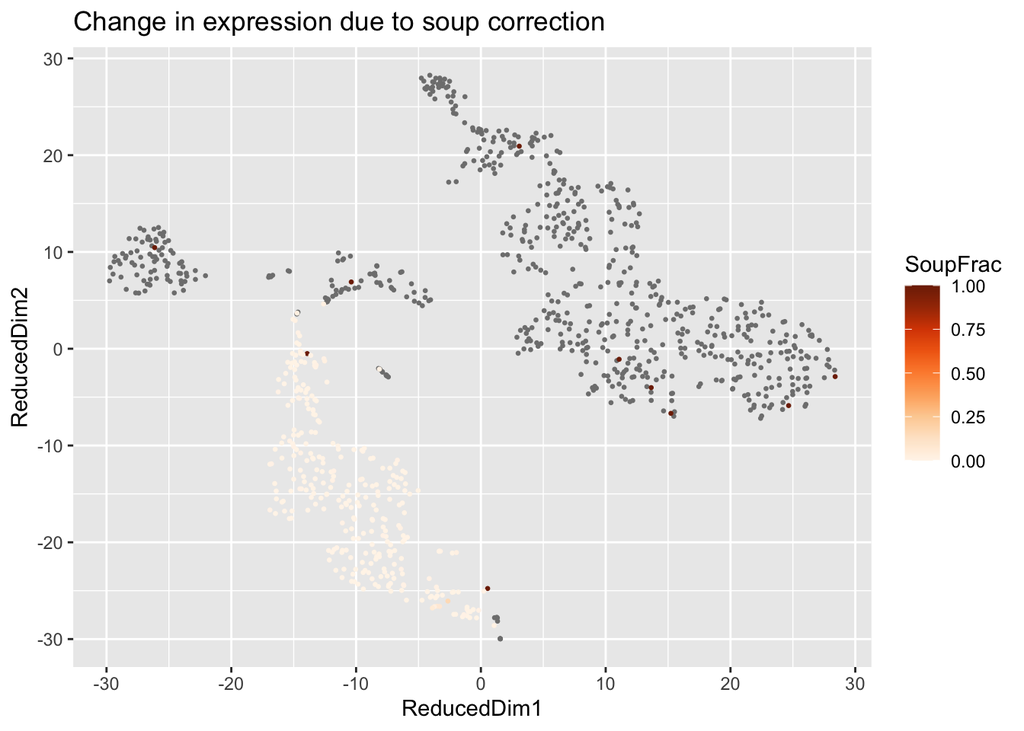

```r
SoupX::plotChangeMap(sc, out, "LYZ")
```

The scattered `LYZ` expression outside the monocyte cluster is the part that gets removed, while the monocytes keep their counts. Our lysozyme-producing T cells were contamination, and the correction has recovered the biology we expected without being told any of it — SoupX was never given a cell-type label.

Try this with other genes and watch which change and which do not — `CST3`, `S100A9`, `GNLY`, `CCL5`, `NKG7`, `IL32`, `CD74`, `CD8A` are all instructive, and the first four appear on the `most_zeroed` list above. The pattern to notice is that the largest changes hit genes that are highly expressed but only in a specific context. Genes expressed at a similar level everywhere barely move, because the soup and the cell agree about them.

# 10 Using the cleaned matrix downstream

There is no need to write anything to disk. `out` is a count matrix, so it goes straight into Seurat wherever the raw matrix would have:

```r
pbmc <- Seurat::CreateSeuratObject(counts = out)
```

From here you would proceed exactly as in Week 1 — quality control, normalization, feature selection, dimension reduction, clustering — except that your counts no longer contain a systematic contribution from the cells that fell apart before you captured them.

Note that this correction is per-channel. If you have several samples, run SoupX separately on each one — each has its own soup — and combine afterwards, making the cell barcodes unique as you go.

# 11 What we glossed over

This tutorial was deliberately the hands-off route. Several things were taken on trust:

- **The automatic `rho` estimate.** We accepted `autoEstCont()`’s answer without checking it — and on this dataset that answer landed on the boundary of its own search range, which is precisely the situation where you would most want a second opinion. `soupx_handson.R` estimates the same quantity manually, by naming genes we are confident a cell does not express and measuring them directly. That path is the one you need when the automatic method fails or is unavailable.
- **`contaminationRange = c(0.01, 0.8)`.** We never questioned the search range, despite the estimate sitting on its floor.
- **Clustering came for free.** Every convenience in this document traces back to the `analysis/` folder. If your data were not processed with CellRanger — a Parse or plate-based experiment, or a count matrix someone handed you — you have no `analysis/` folder, and both the estimation and the correction need clusters supplied by hand. Again: `soupx_handson.R`.
- **We never had empty droplets in question.** SoupX needs the raw, unfiltered droplet table. If all you have is a filtered count matrix, the soup cannot be observed and this method does not apply as written.
- **The default `soupRange = c(0, 100)`.** Which droplets count as “empty” is a parameter, and we used the default.
- **`rho` was assumed constant across cells** in the channel. The paper shows this is reasonable for 10x data, but it is an assumption.
- **How representative this dataset is.** Fresh PBMCs prepared by 10x as a demonstration are close to a best case. At `rho = 0.01` the correction barely had to do anything, so this tutorial shows you the *mechanics* on easy data rather than the stakes on hard data. Postmortem brain and nuclei preparations — which is most of what this room is working with — are where the effect is large.
- **Whether to do this at all.** Ambient RNA correction is not universally applied, and it is not free — you are modifying your counts before you have looked at them. The diagnostics in this document are how you justify the decision. Being able to point at the `LYZ` change map, and at a `rho` you measured, is worth more than citing the package.

# 12 References

- Young MD, Behjati S. *SoupX removes ambient RNA contamination from droplet-based single-cell RNA sequencing data.* GigaScience 9(12), 2020. [doi:10.1093/gigascience/giaa151](https://doi.org/10.1093/gigascience/giaa151)
- The SoupX package vignette, on which this tutorial is closely based: [PBMC tutorial](https://rawcdn.githack.com/constantAmateur/SoupX/204b602418df12e9fdb4b68775a8b486c6504fe4/inst/doc/pbmcTutorial.html)